Panelwright · Development record · 2026-08-06 to 2026-10-29 · story told to 2026-09-14, key figures refreshed 2026-10-29 · prepared for a management briefing

# The Making of *Panelwright*

Panelwright is "Playwright for the IBM 3270 terminal": a pure-TypeScript tool that lets people and AI agents drive mainframe green-screen applications. It was built over twelve weeks by one engineer (the story below follows the first five) working with Claude as a full-time pair, with two colleagues joining for real work. This page tells how, in the order it happened, with the numbers and the mistakes left in.

60 / 85

days with commits, out of 85 calendar days from the first commit to 2026-10-29 (all of the first 40)

40 h

of one person's attention in the first 40 days (measured to 2026-09-14)

1,118 / 1,136

commits carry Claude as co-author

425

tickets shipped or closed with a note

$10,250

of model usage at list price for the first 40 days (to 2026-09-14); the subscription it really ran on costs $100–200

9,563

automated tests; more test code than product code

4

kinds of host it is validated on, from a fake to real z/OS

3

surfaces: CLI for agents, terminal UI, VS Code

**1** · Before the first commit

## The motivation shaped the architecture

Most mainframe applications have no usable API. They exist only as screens. The question was never "can we scrape a screen", it was "can an AI agent work a screen the way it works a web page".

### Three things came together

**The spark.** Petr watched an AI agent struggle for hours with a complex web application, then saw the same agent finish in minutes once it had the Playwright CLI and a skill describing how to use it. The tool was not smarter; it could finally see the page and act on it one step at a time. The mainframe terminal had no such tool.

**The real need.** He had maintenance to apply to his own zD&T system, IBM's z/OS development and test environment, a job that means hours in TSO and ISPF panels. Enabling Claude to do it looked easier, and more interesting, than dusting off his own systems-programmer skills.

**The emulators.** Every existing emulator felt like user experience from the previous century. Basic things that any modern editor has, field completion, visual aids showing where you can type, scripting in an open, modern language, would obviously make the daily work of a person more ergonomic too. So the tool had to serve both audiences from the start.

The requirements document written on day one names the goal directly: the primary success metric is that *AI agents can operate mainframe applications successfully through this tool*. Everything else followed from that sentence.

- **CLI first.** An agent working through one command per action gets compact feedback after every step and can adapt. Writing blind scripts against a screen it cannot see does not work. So the command line, not a library, is the front door.
- **Locators, not coordinates.** A 3270 screen has no field names. Forty years of terminal automation addressed fields by row and column, which is why recorded scripts rot. Panelwright addresses a field by the text next to it: `after:"Userid"`, `below:"Command ===>"`. Every existing tool surveyed was coordinate based, and their issue trackers showed users asking for text-relative addressing for years.
- **Pure TypeScript.** The existing emulators (x3270, c3270) work but are C programs that cannot be embedded in a Node.js tool, a VS Code extension or an agent runtime. Portability was the reason to rewrite.
- **Humans stay in the loop.** The same session an agent drives must be watchable, and takeable, by a person. That requirement later became the handoff protocol and supervised mode.

$ panelwright type after:"Logon ===>" HERC01 $ panelwright press ENTER [tso-logon] fp:6e21 cur 8,22 fields 6 unlocked ENTER USERID - PASSWORD FOR HERC01 [2:________] … 21 unchanged rows not shown after each action the CLI prints only what changed: ~150 characters instead of a 2,000-character screen dump

The compact diff is the contract between the tool and the agent. It was validated in a throwaway spike before any product code existed: 355 characters instead of 2,294 for a logon screen, an 84% reduction, with every typeable field still marked.

**2** · 2026-08-06 to 08-07

## Research before code

The first two days produced no product. They produced a market survey, a protocol audit, a reading list and a set of decisions, all written down so they could be cited later.

### What is out there

Claude surveyed the 3270 emulator market end to end: the open-source x3270 family (x3270, c3270, wc3270, wx3270), dm3270, DX3270, Vista, Mocha, web3270, Zowe's tn3270-ng2, and the commercial tools every enterprise has installed: IBM Personal Communications, Host On-Demand, Micro Focus Reflection and EXTRA!, Ericom PowerTerm, Rocket Rumba. For each it recorded the two things every emulator must decide (how input fields are shown, what happens to space beyond the grid), the keyboard conventions, and which features were worth stealing. PCOMM's clickable hotspots on `F3=Exit` legends became a Panelwright feature; the universal F1 to F12 mapping became the default.

It also collected what users actually say. The clearest signal in the research set was a Zowe feature request asking for "x3270-style scripting, but modern", and a Hacker News thread from someone who had scraped hundreds of 3270 applications with EHLLAPI calling it "a very difficult attempt". That is the pain relative locators exist to remove.

### What could be reused

The audit of existing JavaScript libraries settled the biggest build-or-buy question in an afternoon. The only `tn3270` npm package was 150 lines of Telnet negotiation and nothing else. A second project had a real data-stream engine but no license. Zowe's engine was a 720 KB minified blob committed to its repository. Verdict: implement the protocol from scratch, reuse one small EBCDIC code-page package, and treat x3270's C source as the reference to derive from, not copy.

### What was read

- The x3270 source, function by function, for the exact semantics of orders like Program Tab and the keyboard-lock state machine. Recorded in a derivations document with attribution.
- The Hercules emulator's console code, the TN3270 server behind the MVS test host, to understand why a wrong terminal type causes an error loop.
- IBM's 3270 Data Stream Programmer's Reference (GA23-0059), the RFCs for TN3270E, and Petr's self-hosted index of vendor mainframe documentation for byte-level questions.
- Prior art for locators: py3270, Robot Framework's Mainframe3270, Galasa's terminal API, HLLAPI, and IBM HATS for screen recognition.

**Evidence discipline.** Every research claim was tagged `[doc]` (vendor or IETF text), `[community]` (a forum anecdote) or `[recall]` (the model's own memory, unverified). A tag of `[recall]` meant "treat as a lead, not a fact". That convention is what kept model hallucinations out of the design record.

**3** · 2026-08-06 to 08-07

## Spikes before commitments

Petr's working rule from the start: brainstorm, research, then validate with a throwaway prototype before writing product code. The spikes are frozen in the repository and never edited.

1. **Protocol spike: can a pure-TypeScript client log on at all?** 1,232 lines of code logged on to Galasa SimBank, a Java fake bank application that speaks real TN3270. Two findings changed the plan: the newer TN3270E protocol was mandatory, not optional (SimBank refuses the classic fallback), and the parts everyone feared worked first try while the friction was in field ordering during negotiation.
2. **Locator spike: does text-relative addressing work?** Yes, including composition ("after Name, below Section") and the list-every-candidate error when a label is ambiguous. It also found the shakiest piece, deciding which text fragments form one label, and flagged it for testing against real panels.
3. **End-to-end spike, driven by an agent.** Claude itself, unscripted, drove a line-protocol prototype through logon, a routing screen, a menu and an account browse. It was also the experiment that chose the command grammar. The predicted winner was "type into field number 1". The agent immediately put an account number into the command line, because field 1 was the command line. The self-documenting `after:"Account Number"` form won on the evidence, with numbers kept as a fallback.
4. **Terminal UI phase zero.** Measured whether a React-based terminal UI could repaint a 24 by 80 grid fast enough: a single-row change cost under a millisecond, 20 to 35 times the headroom needed. Both top implementation risks retired with numbers before the UI was started.
5. **VS Code spike.** Proved the split between a webview that owns the screen and the extension host that owns the socket, and that keyboard capture works, before the extension was designed.

**4** · Decided 2026-08-06, still standing

## The decisions that shaped everything

**A daemon, because CLI processes die and sessions cannot.** Each CLI command is a fresh process, but a mainframe session is a live TCP connection with state. The unstated problem in the requirements became the central design: a small per-user background service holds the sessions, and the CLI, the terminal UI, the VS Code panel, user scripts and any future MCP server are all thin clients of it. An agent can explore in the CLI while a person watches the same session in VS Code.

**Build order: protocol and fake host, then locators and compact output, then CLI, then the terminal UI, then VS Code.** Each layer was validated against a real host before the next started. The terminal UI was deliberately second, cheap once the daemon existed. VS Code came last, as one more client, after Petr had collected fifteen raw requirements from his own daily use and Claude had decompiled an abandoned competitor extension to learn from its architecture.

**Waiting, done right.** Decades of automation failures come from treating "keyboard unlocked" as "screen finished". Panelwright waits automatically after every action for the host to go quiet, and its timeout errors attach the current screen and the lock reason, so for an agent a timeout is a navigation aid rather than a failure. The defaults were measured on both test hosts, not guessed.

**5** · The whole period

## Building to a backlog

From 2026-08-13 every piece of work has a permanent ticket id. A ticket's row moves from the backlog to the shipped record in the same commit that ships it, carrying a ship note. Nothing is deleted.

The repository is also the AI's operating manual. A `CLAUDE.md` file at the root and one in each package hold the hard-won facts a new session needs: commands, hazards, credentials for the test hosts, and the rules that came out of mistakes. The convention is explicit: *knowledge lives in the repo, not in private session memory*, and an outdated instruction file is a bug fixed in the same commit as the surprise that exposed it. A domain glossary pins the vocabulary, with a list of banned near-synonyms for each term. Design records keep numbered owner decisions, rejected alternatives and superseded mockups on purpose, so nobody rebuilds what was removed.

Commits per day on the main branch, both authors. Hover a bar for the date. Emil Kotrc's first commit is 2026-08-28.

**08-06**

First commit. The same evening the client logs on to real TSO on MVS 3.8j running under Hercules in Docker.

**08-07**

CLI and daemon. Terminal UI research and plan; eleven owner decisions taken in one sitting.

**08-08**

Claude Code skill and installer. First scored agent evaluation runs.

**08-09**

Terminal UI v1.1 accepted after a live acceptance script; three features removed.

**08-10**

First session against a real z/OS host. Two protocol defects the test hosts could never show.

**08-13**

Configuration and profiles. The backlog is created; future work had been scattered across six documents.

**08-14**

Agent-to-human handoff, all four phases. Screen sizes and terminal models.

**08-25**

Scripting language ships. KICKS and DOGECICS installed on the test host entirely through the CLI.

**08-27**

External feedback: another agent drives three real lab hosts. Eleven fixes shipped the same day.

**08-28**

The in-house usage campaign, sixteen sessions. Emil joins.

**08-30**

VS Code extension design (27 decisions) and first phase.

**09-05**

TKDB, a SQL engine for MVS built by Emil as a real application to drive.

**09-06**

VS Code handoff validated with the real Claude Code extension as the agent.

**09-07**

Supervised mode: every transmit an agent sends can be gated behind a human.

**09-10**

Colour system for VS Code themes, eleven owner decisions from a bench, shipped and accepted the same day.

**6** · Built 08-06 onward

## The hosts we own

Real customer mainframes are unreachable from a laptop and always will be. The project built and bought a ladder of substitutes, each catching a class of defect the one below cannot.

[output not shown]

**The differential oracle.** When Panelwright misbehaves against a host that other emulators handle, the rule is to drive that host with x3270's scripting build first and diff the two traces. Running the same ten-step TSO scenario through both found the client's field derivation matched x3270 at nine of eleven checkpoints and exposed a bug that would have refused keystrokes on almost every second TSO command.

**The blind spot, found by a person.** On 2026-08-10 Petr ran Panelwright against a real z/OS system for the first time. Two "minor issues" were real protocol defects: null characters in a field were transmitted back to the host as periods, and every input field on a real ISPF panel appeared to start one column early. The MVS test host emits neither feature, so no hermetic test could ever have caught them. Both were diagnosed from c3270's decoded trace because Panelwright's own trace was unreadable hex. The fix included a readable trace decoder, on the principle that a diagnostic nobody can read is not a diagnostic.

[figure not shown]

The CLI logging on to TSO on the MVS 3.8j test host, captured live on 2026-08-27 with Panelwright's own screenshot tooling. Fields are addressed by the label next to them; only changed rows are printed.

**7** · Five stages, 08-06 to 09-11

## How testing changed hands

Testing started as Petr using the tool and telling Claude what was wrong. It ended with Claude running real installation jobs, headless agent campaigns and a scored evaluation, and with a rule that no agent's claim counts until an artifact backs it.

1. **Human feedback, unit tests written by the AI.** In the first week Petr tested by hand and sent findings; Claude wrote the fixes and pinned each with a test. This is where the test-to-code ratio was set: today there are more lines of test than of product.
2. **Live measurement after green suites lied.** During the terminal UI's v1.1 round, three features passed full unit suites and failed in a real terminal: a version probe that swallowed every keystroke typed at startup (0 of 12 delivered versus 7 for the control), a hardware cursor that made every frame render twice, and mouse clicks landing rows off. All three were removed. The rule that came out of it: for anything touching keyboard input, the cursor or rendering, a green suite is not evidence. Measure in a real pseudo-terminal against a control that differs in one variable.
3. **Claude uses the tool for real work.** On 2026-08-25 Claude installed KICKS, a CICS clone, on the test host purely through the CLI: an 8.5 MB binary upload, a terminal-driven job submission, polling the job queue. The install hit a genuine blocker, a raw-typing capability the CLI did not expose, fixed the same night. DOGECICS the same day found a chain of three defects: a command silently truncated to 25 characters, the host stuck in a prompting loop, and a transfer timeout blaming the wrong cause. Then the campaign: sixteen headless agent sessions across every interactive application on the host, one day, $29.31, eleven tickets filed. Each session ran the packed release tarball from a directory outside the repository, so it could see only what a user sees.
4. **A scored evaluation, and an outsider probe.** The evaluation harness runs the same tasks with three models under nested documentation conditions and verifies every outcome against the live host, never against the agent's own report. The headline: with a one-page cheat sheet, the cheapest model went from 15 of 18 to 18 of 18 and matched the frontier model. Without it, it tripped documented hazards and once invented a screen that did not exist. Separately, when the question was "can someone without this repo do X from what ships", a fresh agent restricted to the shipped artifacts was given the real task; it found three bugs the project's own tests never had.
5. **An outside tester, on hosts nobody here can reach.** On 2026-09-11 Dan, outside the team and running the rolling edge build rather than a checkout, drove Panelwright against Broadcom lab systems over TLS and reported by pasting his output channel verbatim. Twenty-five lines a maintainer would have read as ordinary startup noise produced six tickets, five of them fixed the same day. The timestamps were the evidence: a 10.2-second gap between “daemon started” and “attached” was a connect being reported as successful against a host that had accepted the socket and then said nothing at all.

**The rule that keeps the record honest.** Round one of the usage campaign filed four confident, evidence-cited defect claims from agent testers that turned out to be wrong on inspection, including a "blocker" that was correct 3270 hardware behaviour. Since then every finding must name an artifact a reader can open, a verbatim command plus a journal entry or trace timestamp, or it is dropped at triage without discussion. The same rule applies to Claude's own subagents: a measurement with no artifact is not a measurement.

**8** · A selection

## Who could see it

The most useful way to understand the collaboration is by which defects each party could perceive. Some were visible only to a person at a real terminal. Some were visible only to an agent running a thousand-step task. Some were visible to neither until the two were diffed.

| Defect | Seen by | How, and why nothing else could |
| --- | --- | --- |
| A real password captured in plaintext by the field-completion cache | Petr | An evening of live use. Four hermetic tests for the feature passed. The completion shipped green and did nothing at all until a person typed into it. |
| Visible flicker between two prompt screens; slowness on real-sized screens with a hundred-plus fields | Petr | Ink's test renderer has no frames to flicker and the test host has no 62 by 160 panels. Both are now items on the live-validation checklist: real screen size, real field count, timed. |
| SYSVIEW's activity bars rendered as grey blocks | Petr | Looked wrong on a real host. Led to the discovery that reverse video was dropping the host's own colour, then to the colour bench. |
| Nulls transmitted as periods; every ISPF field off by one column | Petr | First real z/OS session. The MVS test host emits neither nulls nor extended attributes, so the defects survived every test that existed. |
| Startup keystrokes swallowed; double-rendered frames | Claude | Live pseudo-terminal measurement against a control, counting delivered keys and frames. Unit tests with a fake stdin passed at every stage. |
| Keystrokes refused on wrapped TSO input fields | Claude | The same session run through x3270 and Panelwright side by side, diffed cell by cell. |
| Binary file transfer corrupted 198 of 201 bytes while both ends reported success | Claude | The headless usage campaign. A human doing one transfer would have trusted the success message. |
| Typed command silently truncated; raw typing not exposed | Claude | Installing DOGECICS and KICKS through the CLI, the first real multi-hour tasks the tool was used for. |
| The TSO `***` pager loop, "the biggest remaining footgun" | another agent | An external Claude Code agent driving three real lab hosts with ~70 commands. Its feedback file became eleven fixes in a day. |
| Mid-transfer idle timeout; silent line truncation into 80-column data sets | Emil | His daily loop of sending 100 KB REXX programs into a data set and submitting jobs. Filed as backlog rows from "a day of real driving". |
| A connect reported as successful against a host that accepted the socket and then went silent; a healthy cold start logging red errors every five seconds | Dan | An outside tester on a Broadcom lab host over TLS, running the packaged build. No one on the project has that host, and in a log both defects read as normal startup noise until the timestamps are read… |
| A model inventing a plausible ISPF tutorial title that existed on no screen | the eval harness | Every predicate is checked against the live host. This is why agent self-reports are never scored. |
| An install job reporting complete success while skipping every real step | the Docker build | A cosmetic continuation dash made a conditional cover one statement instead of three. Only an unattended batch replay of the install could expose it. |

**9** · 08-13 onward

## Feedback from people

**Petr** owned every decision. The design records number them: eleven for the terminal UI in one sitting on 2026-08-07, six for the Claude Code integration, twenty-seven for the VS Code extension, eleven for colours. His feedback arrived as short verdicts on things Claude could not perceive: "it flickers", "this is slow", "the colours are wrong on SYSVIEW", and once, overriding a design document that had shipped the day before, "no ghost suggestion, just show the completion list". That feature had no way to accept the suggestion; pressing Enter dismissed it and sent a bare key to the host.

**Vít** never committed code. On 2026-08-17 he independently asked for two things that became tickets: custom key bindings and a scripting language, with the note that he wants to write his own macros. That sentence decided the scripting design's authoring surface. He raised the window-resize question, and in September proposed a Zowe Explorer provider so Panelwright sessions could live in the tooling mainframe developers already use; he answered nine design questions on it this week.

**Emil** joined on 2026-08-28 for real MVS work and has 92 commits since. He built TKDB, a DB2-like SQL engine on the 1981 operating system, as a serious application to drive, and researched authorised assembler programming on the host. Everything on the file-transfer and 80-column path landed on him first, and he gave feedback the way the project prefers: as decision-complete backlog rows and as hazard notes written straight into the instruction files. Two humans pushing to one branch also produced the project's first ticket-id collision, when both filed the same number on the same day; the fix was a renumber and a fetch-before-push rule.

**Dan** has never run the source. On 2026-08-13 he asked for three things and all three shipped: a simple scripting language, custom key bindings, and wallpaper or animated GIFs behind the screen with an animated cursor. The first became the largest single feature in the project — a design memo to settle what “simple” meant, then four phases of build; rebindable keys shipped on 2026-08-24. The third looked like the frivolous one and turned out to be an architectural argument: a terminal emulator cannot composite an image behind a character grid, so the request could only ever be answered by the VS Code webview, which is where it shipped on 2026-08-31, pulled forward out of its phase. It arrived with five cursor effects rather than the three the design named, after Petr was shown how two existing VS Code extensions do it and picked all of them.

**Dan again, four weeks later.** On 2026-09-11 he became the project’s first outside tester on hosts nobody here can reach: Broadcom lab systems behind a TPX session manager, on a TLS port that is a vendor convention rather than the registered one. His host offers a 1024-bit Diffie-Hellman group that Node refuses by default, making it the first real system to exercise the relaxed TLS path built a week earlier against a report, not a host. It also exposed the defect that path had shipped with: a connection repaired in three steps saved only the last of them, so the profile it had just “fixed” failed the same way on the next connect.

**An outside agent.** On 2026-08-27 a Claude Code agent in another team used the packaged release to verify three lab systems with different security products. Its written feedback praised the diff output ("full screens were needed maybe eight times in seventy actions") and listed the line-mode pager as the biggest remaining trap. That day is the template the in-house campaign copied: the cheapest quality signal the project ever bought.

[figure not shown]

Watch mode in the terminal UI: a person observes the session an agent is driving, and can take control. The handoff protocol was designed from three scenarios Petr dictated by voice.

**10** · 08-07, 08-19, 09-10

## Designing things the AI cannot see

Claude cannot look at a terminal. It can measure one. For anything aesthetic the working pattern became: derive the rules from research, build several real candidates, and put them side by side in front of a person.

**Rules from research.** The terminal UI's principles were distilled from Claude Code, lazygit, k9s, btop and the emulator survey: density is task dependent and this tool is two tasks at once, colour discipline, a persistent footer plus a help overlay plus a command palette for discoverability. The keyboard budget was allocated in one pass so it would not be relitigated per feature. The palette is on Ctrl+P and never on a bare slash, because a slash is common mainframe data and the host parks the cursor in a field on nearly every panel.

**Benches for judgement calls.** Petr asked for it directly: "give me a web page I can open on my phone for judging". Since then a visual question is answered with a published page that runs the real rendering code over a real captured screen at the shipped value and two or three candidates, with a verdict block he pastes back. For the VS Code colour work Claude drove a real VS Code window through forty themes with Playwright, measured contrast, and found that a quarter of theme files set no terminal palette at all and that 3270 "white" was invisible on one popular light theme. Petr took eleven decisions from the bench on 2026-09-10; they shipped as seven commits the same day and he tested the result against a real mainframe: "looks great".

**Removed on a person's verdict.** A "smart" highlight mode that guessed which fields you care about was recalibrated once and then dropped, because a rule that guesses what matters is one the user has to model in their head. The reasoning for every removed feature stays in the repository so it is not rebuilt.

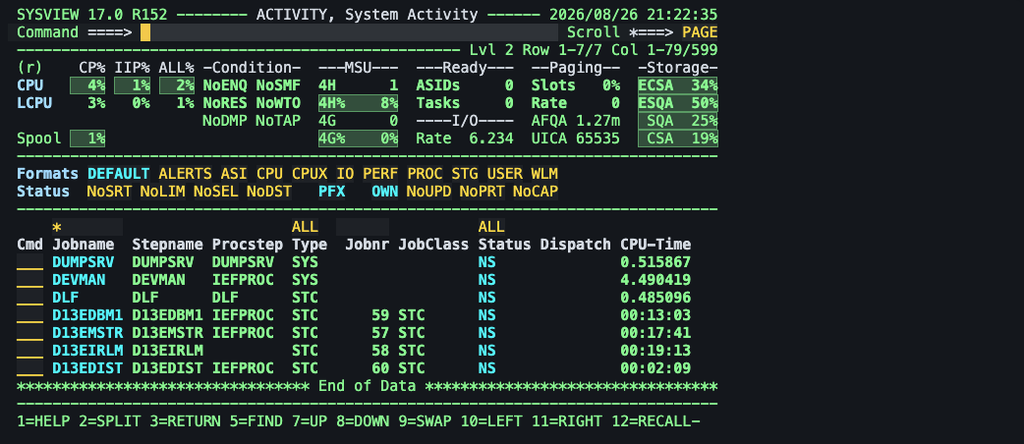

[figure not shown]

The same screen under ISPF Green, one of the four themes the extension contributes: a forced classic look for people who want the emulator to look like the emulator they grew up with.

**11** · What shipped

## One session, four ways in

- **The CLI**, one command per action, compact diffs, exit codes that carry the candidates when a locator misses. Passwords come from the environment and are redacted from the journal and wire traces by construction.
- **The terminal UI**: a live, faithful screen with a locator picker, palette, autocomplete, mouse, file transfer, hotspots, and a watch mode for observing an agent.
- **The VS Code extension**: the same session in an editor panel, links from data set names on screen into Zowe Explorer, and the handoff protocol, validated on 2026-09-06 with the real Claude Code extension as the agent.
- **For agents**: a Claude Code skill installed with one command, an action journal for reviewing what an agent did, supervised mode where each transmit waits for a person's approval, and a scripting language for turning an explored path into a reusable spec. Structured message ids in the mainframe style, generated from a catalog, so an error can be looked up.

Not yet: publication to npm and the VS Code Marketplace, and the MCP server, each with its ticket and its trigger.

**12** · Counted 2026-10-29 (hours, tokens and dollars: 2026-09-14)

## The month, counted

Every figure below is a count taken from the repository as of 2026-10-29, except the hours, messages sent and tokens, which come from 202 session transcripts counted on 2026-09-14, and the money, which is an estimate with its method stated.

*Refreshed 2026-10-29: the repository counts (lines, tests, messages, commits, tickets) were re-measured at that date. Hours, messages sent, tokens and dollars were not: Claude Code has since pruned those early transcripts (14 remain, starting 2026-09-24), so they stay as of 2026-09-14 and cover the first 40 days only.*

What it took

40hours

of one person’s attention, spread across the first 40 calendar days (to 2026-09-14) — plus a subscription shared with other work

instead of

What it would have taken

2–4person-years

to hand-build a smaller equivalent library — €200,000 to €400,000, arriving 18 to 30 months later

347,000

lines of product and test code

1.12 : 1

test code to product code

637

distinct messages, each explained

75,921

lines of human-facing documentation

2,128

messages from one person, 202 sessions (to 2026-09-14)

13.2 bn

tokens, about $10,250 at list price (to 2026-09-14)

What the repository contains

| What | Files | Lines |
| --- | --- | --- |
| Test source | 757 | 183,856 |
| Product source | 665 | 163,459 |
| Human-facing documentation | 138 | 75,921 |
| Captured fixtures and wire traces | 137 | 63,762 |
| Tooling and release scripts | 104 | 22,387 |
| CLI help text | 33 | 4,175 |

There is **more test code than product code** — 1.12 to 1. The 9,563 executed tests (3 more are skipped) come from 8,495 declared cases across 757 files, carrying 19,818 assertions, and they run in six automated kinds: hermetic unit tests, captured host traces replayed through the real parser, a TN3270E server that reimplements the framing so a client bug cannot hide inside its own test double, daemon end-to-end over real sockets, CLI end-to-end against the built binary, and VS Code UI tests driving a real webview. Three more kinds — a real terminal, live mainframes, and an agent-evaluation harness — are run by hand.

The product can print **637 distinct messages** — 374 errors, 130 warnings, 133 informational — each with its text, why it happens and what to do about it. That catalog renders to a printable reference attached to every release.

### What it took, and what it would have taken

The model side ran 44,545 turns for **13.2 billion tokens**, 98% of them context re-read on every turn. At Anthropic list prices that month would bill about **$10,250**; it actually ran on a subscription costing a hundred or two hundred dollars, shared with other work.

**The counterfactual, stated carefully.** Written by hand at 300 delivered lines per working day — already generous with modern completion tooling — the same 347,000 lines of code is about 5.3 person-years. But nobody would write 347,000 lines to solve this problem. A person would build a working 3270 library with decent tests, adequate documentation, a CLI and an extension, and that is a **two to four person-year product**: roughly €200,000 to €400,000 at a €100k loaded rate, arriving eighteen to thirty months later. The honest claim is not a speed multiplier. It is that **thoroughness stopped being the thing you trade away to ship** — the tests, the 637 explained messages and the design records are the part a deadline usually takes first.

**13** · For the briefing

## What this shows about building with AI

#### People did

- The motivation and the non-negotiables on day one.
- Every numbered decision, usually chosen from researched options with a recommendation.
- Access to real z/OS, and the eyes at the real terminal.
- Verdicts on taste and on scope: remove this, only these three things, stop and ask.
- Real work that stressed paths nobody had planned to test.

#### Rules that emerged

- A measurement without an artifact a reader can open is not a measurement.
- When an automated run shows a symptom, suspect the harness before the product. Four of five apparent defects in one pass were the driver.
- Knowledge lives in the repository, not in the chat. A stale instruction file is a bug.
- A green test suite is not evidence for anything a person perceives. Measure in a real terminal, on a real-sized screen, before decoration arrives.
- Verify what ships, not what is in the tree: install the tarball and look.

**Speed came from the loop, not from typing faster.** The eleven-fixes-in-a-day episodes were possible because research, decision, implementation, test and record were one conversation. The cost of that speed was a new failure mode: confident, well-formatted findings that were wrong. The project's answer was procedural, not technological. Verify against the artifact, every time.

**The human's job moved up, not away.** Of 1,136 commits, 1,118 carry Claude as co-author. Petr decided, looked, used the tool for real work, and said what he saw. The tool exists because someone could say "it flickers".

**An AI-friendly tool is a human-friendly tool with a journal.** Compact output, actionable errors, a watchable session and a way to hand control back turned out to be what both audiences needed. The scored evaluation's finding that a one-page cheat sheet lets the cheapest model match the frontier is the same finding as "write the docs".